# Most Hazardous Weather Events in the U.S.

Reynaldo Vazquez

9/07/2017

## Synopsis

The following analysis addresses two questions:

1. In the U.S., what weather events have been the most harmful to population life and health?
2. In the U.S., what weather events have been the most economically devastating?

This analysis uses data from the U.S. National Oceanic and Atmospheric Administration’s (NOAA) storm database. The database tracks characteristics of major storms and weather events in the United States, including date and location, estimates of fatalities, injuries, and property damage. The records start in 1950 and end in November 2011.

## Data Processing

Data was downloaded from [here](https://d396qusza40orc.cloudfront.net/repdata%2Fdata%2FStormData.csv.bz2) on September 7, 2017. The full raw dataset was loaded into R and processed by discarding variables not relevant to this analysis. Other transformations and manipulations are described throughout the document.

1. Load required packages

```r
require(dplyr); require(ggplot2);require(knitr); require(pander)
require(kableExtra);require(gridExtra);require(reshape2)
```

2. Load full dataset

```r
fulldata <- read.csv("repdata-data-StormData.csv.bz2", stringsAsFactors = FALSE)
```

3. Inspect variable names to discard those non-relevant

```r
names(fulldata)
```

```
##  [1] "STATE__"    "BGN_DATE"   "BGN_TIME"   "TIME_ZONE"  "COUNTY"
##  [6] "COUNTYNAME" "STATE"      "EVTYPE"     "BGN_RANGE"  "BGN_AZI"
## [11] "BGN_LOCATI" "END_DATE"   "END_TIME"   "COUNTY_END" "COUNTYENDN"
## [16] "END_RANGE"  "END_AZI"    "END_LOCATI" "LENGTH"     "WIDTH"
## [21] "F"          "MAG"        "FATALITIES" "INJURIES"   "PROPDMG"
## [26] "PROPDMGEXP" "CROPDMG"    "CROPDMGEXP" "WFO"        "STATEOFFIC"
## [31] "ZONENAMES"  "LATITUDE"   "LONGITUDE"  "LATITUDE_E" "LONGITUDE_"
## [36] "REMARKS"    "REFNUM"
```

4. Select needed variables and analyze their structure

```r
data <- select(fulldata, EVTYPE, FATALITIES, INJURIES, PROPDMG, PROPDMGEXP,
               CROPDMG, CROPDMGEXP)
str(data)
```

```
## 'data.frame':    902297 obs. of  7 variables:
##  $ EVTYPE    : chr  "TORNADO" "TORNADO" "TORNADO" "TORNADO" ...
##  $ FATALITIES: num  0 0 0 0 0 0 0 0 1 0 ...
##  $ INJURIES  : num  15 0 2 2 2 6 1 0 14 0 ...
##  $ PROPDMG   : num  25 2.5 25 2.5 2.5 2.5 2.5 2.5 25 25 ...
##  $ PROPDMGEXP: chr  "K" "K" "K" "K" ...
##  $ CROPDMG   : num  0 0 0 0 0 0 0 0 0 0 ...
##  $ CROPDMGEXP: chr  "" "" "" "" ...
```

5. Preprocess event type names

The original data set has 985 *unique* types of events. Many of these seem to belong to a same category of event as others, as can be seen in the example below for hurricanes.

```r
exIdx <- grep("HURR", data$EVTYPE, perl = TRUE)
unique(data$EVTYPE[exIdx])
```

```
## [1] "HURRICANE OPAL/HIGH WINDS"  "HURRICANE ERIN"
## [3] "HURRICANE OPAL"             "HURRICANE"
## [5] "HURRICANE-GENERATED SWELLS" "HURRICANE EMILY"
## [7] "HURRICANE GORDON"           "HURRICANE FELIX"
## [9] "HURRICANE/TYPHOON"
```

The following preprocessing partially solves the issue above by correcting some misspellings, substituting plurals and synonyms, removing excessive space, symbols, numbers, redundancies, and specificities. The purpose is to rename original *event types* that unambiguously belong to the same type.

```r
remove <- grep("summary", tolower(data$EVTYPE), perl=TRUE)
data   <- data[-remove,]
events <- tolower(data$EVTYPE)
events <- gsub("[[:alnum:]]*[.]*[0-9]+", "", events, perl=TRUE, useBytes = T)
events <- gsub("[^[:alpha:][:space:]]|mph", " ", events, perl=T, useBytes = T)
events <- gsub("(?<=hurricane)[ a-z]*", "", events, perl=TRUE, useBytes = T)
events <- gsub("(?<=tropical storm)[ a-z]*", "", events, perl=TRUE, useBytes = T)
events <- gsub("thunde[a-z]*", "thunderstorm", events, perl=TRUE, useBytes = T)
events <- gsub("tstm", "thunderstorm", events, perl=TRUE, useBytes = T)
events <- gsub("floo[a-z]*", "floods", events, perl=TRUE, useBytes = T)
events <- gsub("precipit[a-z]*|rain[a-z]*", "rain", events, perl=TRUE, useBytes = T)
events <- gsub("winds", "wind", events, perl=TRUE, useBytes = T)
events <- gsub("torn[a-z]+", "tornado", events, perl=TRUE, useBytes = T)
events <- gsub("thunde[a-z]*", "thunderstorm", events, perl=TRUE, useBytes = T)
pattrn <- "extr[a-z]*|record|severe|exce[a-z]*|unusu[a-z]*|heavy|major|abno[a-z]*|haza[a-z]*"
events <- gsub(pattrn, "excessive", events, perl=TRUE, useBytes = T)
pattrn <- "astron[a-z]*|weather|temperat[a-z]*|damag[a-z]*"
events <- gsub(pattrn, "", events, perl=TRUE, useBytes = T)
events <- gsub("(?<=[\\s])\\s*|^\\s+|\\s+$", "", events, perl=TRUE, useBytes = T)
reCap  <- function(text) {
    s  <- strsplit(text, " ")[[1]]
    paste(toupper(substring(s, 1,1)), substring(s, 2), sep="", collapse=" ")
}
events <- sapply(events, reCap, USE.NAMES = FALSE)
data$EVTYPE <- events
```

The event type preprocessing above reduced the number of *unique* event categories from 985 to 570. Although this recategorization is not comprehensive, it should suffice for the rest of the analysis. Skipping this recategorization has only limited quantitative effects on the results, whereas the qualitative effects are negligible, at least for the most devastating types of events.

6. Decode PROPDMGEXP and CROPDMGEXP, with their corresponding values. These two variables contain either: a number, or a letter representing the exponent that multiplies their corresponding numeric values in the PROPDM and CROPDMG columns

```r
data$PROPDMGEXP <- tolower(data$PROPDMGEXP)
data$CROPDMGEXP <- tolower(data$CROPDMGEXP)
xfactors <- c("h", "k", "m", "b")
xvalues  <- c("2", "3", "6", "9")
for (i in 1:4){
        data$PROPDMGEXP <- gsub(xfactors[i], xvalues[i], data$PROPDMGEXP, fixed = TRUE)
        data$CROPDMGEXP <- gsub(xfactors[i], xvalues[i], data$CROPDMGEXP, fixed = TRUE)
}
```

7. Transform the PROPDMG and CROPDMG to contain the dollar amounts of their respective damages. Calculate a new variable “TotalDamage”, by adding the two types of damage amounts.

```r
data$PROPDMGEXP <- 10^as.numeric(as.character(data$PROPDMGEXP))
data$CROPDMGEXP <- 10^as.numeric(as.character(data$CROPDMGEXP))
data$PROPDMG    <- data$PROPDMG*data$PROPDMGEXP
data$CROPDMG    <- data$CROPDMG*data$CROPDMGEXP
TotalDamage     <- rowSums(cbind(data$PROPDMG, data$CROPDMG), na.rm = TRUE)
```

8. Tidy up the data by keeping only variables needed and fixing variable names

```r
data <- select(data, EVTYPE, FATALITIES, INJURIES, PROPDMG, CROPDMG)
names(data) <- c("EventType", "Fatalities", "Injuries", "Property", "Crops")
data <- cbind(data, TotalDamage)
```

9. Calculate the sum of total fatalities and injuries by type of event

```r
sums <- aggregate(cbind(Fatalities, Injuries) ~ EventType, data = data, sum)
```

10. Select and rank the 10 weather events with most deaths and most injuries, respectively

```r
tops <- 10
TF   <- head(select(arrange(sums, desc(Fatalities)), EventType, Fatalities), tops)
Rank <- c(1:tops)
TF2  <- cbind(Rank, TF)
TF2[,3] <- format(TF2[,3], decimal.mark=".", big.mark=",", scientific=F, digits = 0)
TI   <- head(select(arrange(sums, desc(Injuries)), EventType, Injuries), tops)
TI2  <- cbind(Rank, TI)
TI2[,3] <- format(TI2[,3], decimal.mark=".", big.mark=",", scientific=F, digits = 0)
deathsTable <- kable(TF2, format = "html", caption = "Table 1: Deadliest Weather Events",
                align=c("c", "l", "r"), col.names = c("Rank", "Type of Event", "Fatalities")) %>%
    kable_styling(bootstrap_options = c("striped","condensed", "bordered"), full_width = F) %>%
    add_footnote(c("period 1950 - 2011"), notation = "alphabet")
injuriesTable <- kable(TI2, format = "html", caption = "Table 2: Events with Most Injuries",
                  align=c("c", "l", "r"), col.names = c("Rank", "Type of Event", "Injuries")) %>%
    kable_styling(bootstrap_options = c("striped", "condensed", "bordered"), full_width = F) %>%
    add_footnote(c("period 1950 - 2011"), notation = "alphabet")
```

```r
deathsTable
```

Table 1: Deadliest Weather Events

| Rank | Type of Event | Fatalities |
| --- | --- | --- |
| 1 | Tornado | 5,633 |
| 2 | Excessive Heat | 2,001 |
| 3 | Flash Floods | 999 |
| 4 | Heat | 937 |
| 5 | Lightning | 817 |
| 6 | Thunderstorm Wind | 705 |
| 7 | Floods | 476 |
| 8 | Rip Current | 368 |
| 9 | High Wind | 283 |
| 10 | Avalanche | 224 |

<sup>a</sup> period 1950 - 2011

```r
injuriesTable
```

Table 2: Events with Most Injuries

| Rank | Type of Event | Injuries |
| --- | --- | --- |
| 1 | Tornado | 91,364 |
| 2 | Thunderstorm Wind | 9,369 |
| 3 | Floods | 6,791 |
| 4 | Excessive Heat | 6,730 |
| 5 | Lightning | 5,230 |
| 6 | Heat | 2,100 |
| 7 | Ice Storm | 1,975 |
| 8 | Flash Floods | 1,785 |
| 9 | High Wind | 1,440 |
| 10 | Hail | 1,361 |

<sup>a</sup> period 1950 - 2011

11. Create graphs showing the events with most deaths and most injuries, respectively

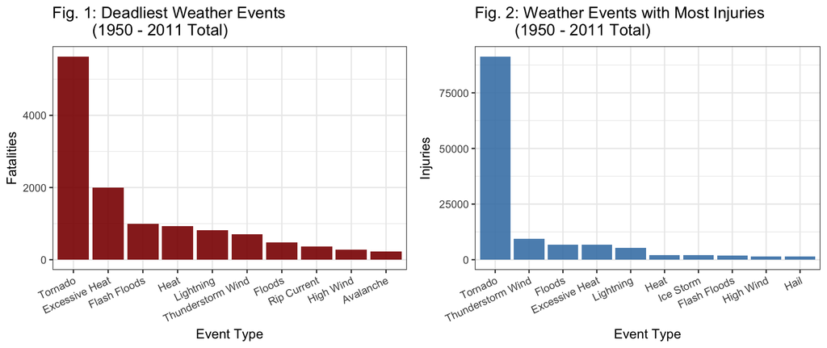

```r
TF$EventType <- factor(TF$EventType, levels = TF$EventType)
g1 <- ggplot(TF, aes(EventType, Fatalities)) +
        geom_bar(stat = "identity", fill = "red4", alpha = 0.9) + theme_bw() +
        theme(axis.text.x = element_text(angle = 25, hjust = 1)) + xlab("Event Type") +
        ggtitle("Fig. 1: Deadliest Weather Events\n         (1950 - 2011 Total)")
TI$EventType <- factor(TI$EventType, levels = TI$EventType)
g2 <- ggplot(TI, aes(EventType, Injuries)) +
        geom_bar(stat = "identity", fill = "steelblue", alpha = 0.9) +theme_bw() +
        theme(axis.text.x = element_text(angle = 25, hjust = 1)) + xlab("Event Type") +
        ggtitle("Fig. 2: Weather Events with Most Injuries\n         (1950 - 2011 Total)")
grid.arrange(g1, g2, ncol = 2)
```

12. Calculate the sum of total damage, property and crops costs by type of event. Then select and rank the 10 costliest weather events

```r
sumsD <- aggregate(x = list(TotalDamage = data$TotalDamage,
                            Property = data$Property,
                            Crops = data$Crops),
                   by = list(EventType = data$EventType), FUN = sum,
        na.rm = TRUE)
TD    <- head(select(arrange(sumsD, desc(TotalDamage)), EventType,
                     TotalDamage, Property, Crops), 10)
```

13. Transform damage values to USD Millions for illustration. Prepare and print table

```r
TDD <- TD
TDD[,2:4] <- round(TDD[,2:4]/10^6, digits = 3)
TDD[,2:4] <- format(TDD[,2:4], decimal.mark=".", big.mark=",", scientific=F, digits = 0)
TDD <- cbind(TDD[,-2], TDD[,2])
TDD <- cbind(Rank, TDD)
kable(TDD, format = "html", caption = "Table 1: Costliest Weather Events (USD Millions)",
                    align=c("c", "l", "r", "r", "r"),
                    col.names = c("Rank", "Type of Event", "Damage to Property",
                                  "Damage to Crops", "Total Damage")) %>%
    kable_styling(bootstrap_options = c("striped","condensed", "bordered"), full_width = F) %>%
    add_footnote(c("period 1950 - 2011"), notation = "alphabet")
```

| Rank | Type of Event | Damage to Property | Damage to Crops | Total Damage |
| --- | --- | --- | --- | --- |
| 1 | Floods | 144,773 | 5,671 | 150,443 |
| 2 | Hurricane | 84,756 | 5,515 | 90,271 |
| 3 | Tornado | 56,952 | 415 | 57,367 |
| 4 | Storm Surge | 43,324 | 0 | 43,324 |
| 5 | Hail | 15,736 | 3,026 | 18,762 |
| 6 | Flash Floods | 17,140 | 1,436 | 18,576 |
| 7 | Drought | 1,046 | 13,973 | 15,019 |
| 8 | Thunderstorm Wind | 9,923 | 1,160 | 11,082 |
| 9 | River Floods | 5,235 | 5,057 | 10,293 |
| 10 | Ice Storm | 3,945 | 5,022 | 8,967 |

<sup>a</sup> period 1950 - 2011

14. Create graph showing costliest events

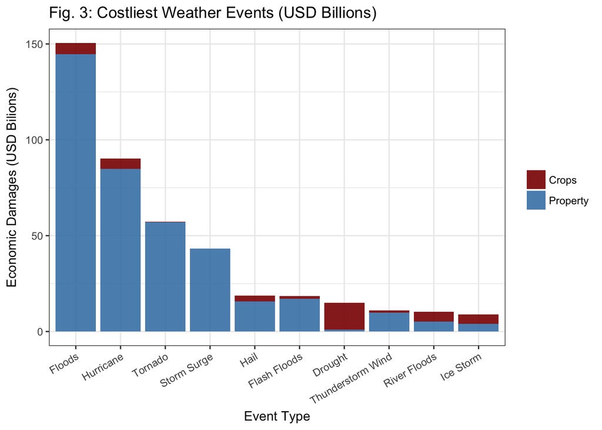

```r
TD$EventType <- factor(TD$EventType, levels = TD$EventType)
TD2 <- melt(TD[,c(1,4,3)], id.vars = "EventType")
ggplot(TD2, aes(x = EventType, y = value/10^9, fill = variable)) +
        geom_bar(stat = 'identity', alpha = 0.9) + theme_bw() +
        theme(axis.text.x = element_text(angle = 30, hjust = 1)) +
        xlab("Event Type") + ylab("Economic Damages (USD Bilions)") +
        ggtitle("Fig. 3: Costliest Weather Events (USD Billions)") +
        scale_fill_manual(values=c("red4", "steelblue")) +
        theme(legend.title = element_blank())
```